# Weather Forecasting

Michele Banfi

2024-09-11

# Project

The aim of the project is to predict the weather given some predictors, such as: `Temperature`, `Dew point`, … since there is no predictor posed as weather forecast, those predictor will be constructured.

## Libraries

Install packages

```r
# install.packages("tidymodels")
# install.packages("tidyverse")
# install.packages("xgboost")
# install.packages("ggplot2")
# install.packages("lubridate")
# install.packages("ranger")
# install.packages("vip")
#install.packages("DiagrammeR")
```

Import the libraries used in the project

```r
library(tidyverse)
library(tidymodels)
library(ggplot2)
library(lubridate)
library(ranger)
library(vip)
library(xgboost)
library(DiagrammeR)
```

## Dataset

The dataset used in this project is composed of hourly observation of weather related features. Available https://huggingface.co/datasets/sayanroy058/Weather-Time-Series-Forecasting

```r
data <- read_csv("dataset.csv")
```

A first visualization of the data

```r
data
```

```
## # A tibble: 389,496 × 17
##    time                temperature relative_humidity dew_point
##    <dttm>                    <dbl>             <dbl>     <dbl>
##  1 1980-01-01 00:00:00        12.7                83      10
##  2 1980-01-01 01:00:00        12.9                82       9.9
##  3 1980-01-01 02:00:00        13.2                82      10.2
##  4 1980-01-01 03:00:00        15.9                78      12
##  5 1980-01-01 04:00:00        19.4                67      13.1
##  6 1980-01-01 05:00:00        21.7                56      12.4
##  7 1980-01-01 06:00:00        23.5                46      11.4
##  8 1980-01-01 07:00:00        24                  48      12.5
##  9 1980-01-01 08:00:00        24.8                45      12
## 10 1980-01-01 09:00:00        25.1                44      12
## # ℹ 389,486 more rows
## # ℹ 13 more variables: `precipitation (mm)` <dbl>, `rain (mm)` <dbl>,
## #   `snowfall (cm)` <dbl>, `pressure_msl (hPa)` <dbl>,
## #   `surface_pressure (hPa)` <dbl>, `cloud_cover (%)` <dbl>,
## #   `cloud_cover_low (%)` <dbl>, `cloud_cover_mid (%)` <dbl>,
## #   `cloud_cover_high (%)` <dbl>, `vapour_pressure_deficit (kPa)` <dbl>,
## #   `wind_speed_10m (km/h)` <dbl>, wind_direction <dbl>, is_Day <dbl>
```

Check for missing values in the dataset

```r
sum(is.na(data))
```

```
## [1] 0
```

Remove the column snow if is all 0. And if that’s the case precipitation and rain are the same and remove one of them

```r
# Check if the 'snow' column is all zeros and remove it if true
if (all(data$`snowfall (cm)` == 0)) {
  data <- data %>% select(-`snowfall (cm)`)
}

# If 'precipitation' is equivalent to 'rain', remove 'precipitation'
if (all(data$`precipitation (mm)`  == data$`rain (mm)`)) {
  data <- data %>% select(-`precipitation (mm)`)
}
```

Now in order to proceed with the computation, the `time` variable can be grouped into daily data averaging by the mean.

```r
data <- data %>%
  mutate(time = as.Date(time)) %>%
  group_by(time) %>%
  summarise(across(-`rain (mm)`, mean), `rain (mm)` = sum(`rain (mm)`))
```

The new grouped data:

```r
data
```

```
## # A tibble: 16,229 × 15
##    time       temperature relative_humidity dew_point `pressure_msl (hPa)`
##    <date>           <dbl>             <dbl>     <dbl>                <dbl>
##  1 1980-01-01        19.6              71.0     13.6                 1013.
##  2 1980-01-02        18.9              69.0     12.1                 1013.
##  3 1980-01-03        18.8              57.6      9.44                1014.
##  4 1980-01-04        20.5              55.8     11.0                 1014.
##  5 1980-01-05        20.2              72.6     14.7                 1015.
##  6 1980-01-06        20.2              73.4     14.8                 1016.
##  7 1980-01-07        21.9              65.2     14.5                 1016.
##  8 1980-01-08        22.7              62.0     14.5                 1016.
##  9 1980-01-09        22.7              61.9     14.4                 1015.
## 10 1980-01-10        22.3              59.7     13.3                 1014.
## # ℹ 16,219 more rows
## # ℹ 10 more variables: `surface_pressure (hPa)` <dbl>, `cloud_cover (%)` <dbl>,
## #   `cloud_cover_low (%)` <dbl>, `cloud_cover_mid (%)` <dbl>,
## #   `cloud_cover_high (%)` <dbl>, `vapour_pressure_deficit (kPa)` <dbl>,
## #   `wind_speed_10m (km/h)` <dbl>, wind_direction <dbl>, is_Day <dbl>,
## #   `rain (mm)` <dbl>
```

Since the data was reduced and grouped, check again for null values

```r
sum(is.na(data))
```

```
## [1] 0
```

Now that the data is ready the data summary can be printed

```r
summary(data)
```

```
##       time             temperature    relative_humidity   dew_point
##  Min.   :1980-01-01   Min.   :14.05   Min.   :16.21     Min.   :-6.704
##  1st Qu.:1991-02-09   1st Qu.:22.33   1st Qu.:47.58     1st Qu.:10.329
##  Median :2002-03-20   Median :23.68   Median :60.96     Median :15.613
##  Mean   :2002-03-20   Mean   :24.13   Mean   :63.95     Mean   :15.233
##  3rd Qu.:2013-04-28   3rd Qu.:25.96   3rd Qu.:85.38     3rd Qu.:21.046
##  Max.   :2024-06-06   Max.   :34.63   Max.   :98.96     Max.   :23.642
##  pressure_msl (hPa) surface_pressure (hPa) cloud_cover (%)
##  Min.   : 994.4     Min.   :930.3          Min.   :  0.000
##  1st Qu.:1007.5     1st Qu.:942.8          1st Qu.:  2.708
##  Median :1010.5     Median :945.7          Median : 16.958
##  Mean   :1010.4     Mean   :945.3          Mean   : 35.153
##  3rd Qu.:1013.6     3rd Qu.:948.0          3rd Qu.: 74.250
##  Max.   :1021.2     Max.   :954.0          Max.   :100.000
##  cloud_cover_low (%) cloud_cover_mid (%) cloud_cover_high (%)
##  Min.   : 0.000      Min.   :  0.000     Min.   :  0.00
##  1st Qu.: 0.000      1st Qu.:  0.000     1st Qu.:  0.00
##  Median : 3.417      Median :  8.375     Median : 10.17
##  Mean   :24.285      Mean   : 16.730     Mean   : 30.08
##  3rd Qu.:53.667      3rd Qu.: 23.542     3rd Qu.: 60.67
##  Max.   :99.750      Max.   :100.000     Max.   :100.00
##  vapour_pressure_deficit (kPa) wind_speed_10m (km/h) wind_direction
##  Min.   :0.02833               Min.   : 2.583        Min.   : 15.25
##  1st Qu.:0.48083               1st Qu.: 7.162        1st Qu.:148.96
##  Median :1.27542               Median : 9.300        Median :236.54
##  Mean   :1.28585               Mean   :10.992        Mean   :204.20
##  3rd Qu.:1.79458               3rd Qu.:14.117        3rd Qu.:258.54
##  Max.   :4.68750               Max.   :31.654        Max.   :338.17
##      is_Day         rain (mm)
##  Min.   :0.4583   Min.   :  0.000
##  1st Qu.:0.4583   1st Qu.:  0.000
##  Median :0.5000   Median :  0.000
##  Mean   :0.5072   Mean   :  2.747
##  3rd Qu.:0.5417   3rd Qu.:  2.000
##  Max.   :0.5417   Max.   :355.200
```

All the variables are numeric, but some of them, such as `wind_direction` has some restriction. `wind_direction` needs to be between 0-360; all the percentage variables, needs to range between 0 and 100. All this checks can be done by looking at the `min` and `max` values of the variables.

Since the `time` variable was grouped, `is_Day` is not any more useful now.

```r
data <- data %>%
  select(-is_Day)
```

```r
data
```

```
## # A tibble: 16,229 × 14
##    time       temperature relative_humidity dew_point `pressure_msl (hPa)`
##    <date>           <dbl>             <dbl>     <dbl>                <dbl>
##  1 1980-01-01        19.6              71.0     13.6                 1013.
##  2 1980-01-02        18.9              69.0     12.1                 1013.
##  3 1980-01-03        18.8              57.6      9.44                1014.
##  4 1980-01-04        20.5              55.8     11.0                 1014.
##  5 1980-01-05        20.2              72.6     14.7                 1015.
##  6 1980-01-06        20.2              73.4     14.8                 1016.
##  7 1980-01-07        21.9              65.2     14.5                 1016.
##  8 1980-01-08        22.7              62.0     14.5                 1016.
##  9 1980-01-09        22.7              61.9     14.4                 1015.
## 10 1980-01-10        22.3              59.7     13.3                 1014.
## # ℹ 16,219 more rows
## # ℹ 9 more variables: `surface_pressure (hPa)` <dbl>, `cloud_cover (%)` <dbl>,
## #   `cloud_cover_low (%)` <dbl>, `cloud_cover_mid (%)` <dbl>,
## #   `cloud_cover_high (%)` <dbl>, `vapour_pressure_deficit (kPa)` <dbl>,
## #   `wind_speed_10m (km/h)` <dbl>, wind_direction <dbl>, `rain (mm)` <dbl>
```

## Predictor

```r
data <- data %>%
  mutate(willTomorrowRain = ifelse(lead(`rain (mm)`) > 0, 1, 0))
```

Set the response variable as a factor

```r
data$willTomorrowRain <- as.factor(data$willTomorrowRain)
data <- data %>%
  filter(!is.na(willTomorrowRain))
```

```r
data
```

```
## # A tibble: 16,228 × 15
##    time       temperature relative_humidity dew_point `pressure_msl (hPa)`
##    <date>           <dbl>             <dbl>     <dbl>                <dbl>
##  1 1980-01-01        19.6              71.0     13.6                 1013.
##  2 1980-01-02        18.9              69.0     12.1                 1013.
##  3 1980-01-03        18.8              57.6      9.44                1014.
##  4 1980-01-04        20.5              55.8     11.0                 1014.
##  5 1980-01-05        20.2              72.6     14.7                 1015.
##  6 1980-01-06        20.2              73.4     14.8                 1016.
##  7 1980-01-07        21.9              65.2     14.5                 1016.
##  8 1980-01-08        22.7              62.0     14.5                 1016.
##  9 1980-01-09        22.7              61.9     14.4                 1015.
## 10 1980-01-10        22.3              59.7     13.3                 1014.
## # ℹ 16,218 more rows
## # ℹ 10 more variables: `surface_pressure (hPa)` <dbl>, `cloud_cover (%)` <dbl>,
## #   `cloud_cover_low (%)` <dbl>, `cloud_cover_mid (%)` <dbl>,
## #   `cloud_cover_high (%)` <dbl>, `vapour_pressure_deficit (kPa)` <dbl>,
## #   `wind_speed_10m (km/h)` <dbl>, wind_direction <dbl>, `rain (mm)` <dbl>,
## #   willTomorrowRain <fct>
```

Plot the response variable to see the distribution

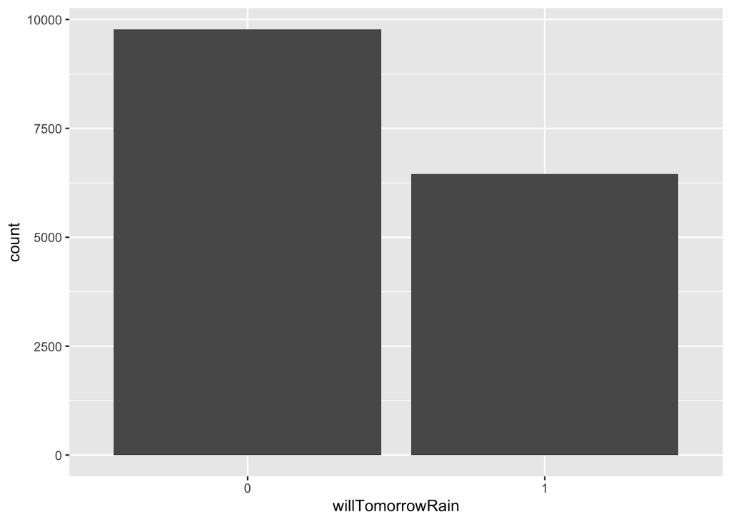

```r
data %>%
  ggplot(aes(x = willTomorrowRain)) +
  geom_bar()
```

Now we plot the distribution of the features to get more insights into the distribution of them

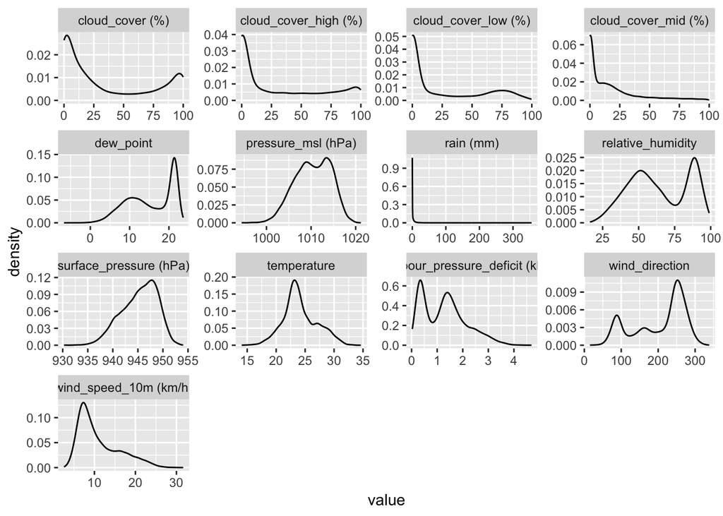

```r
data %>%
  select(-time, -willTomorrowRain) %>%
  gather(key = "feature", value = "value") %>%
  ggplot(aes(x = value)) +
  geom_density() +
  facet_wrap(~feature, scales = "free")
```

Another way to visualize the data is the use of boxplots.

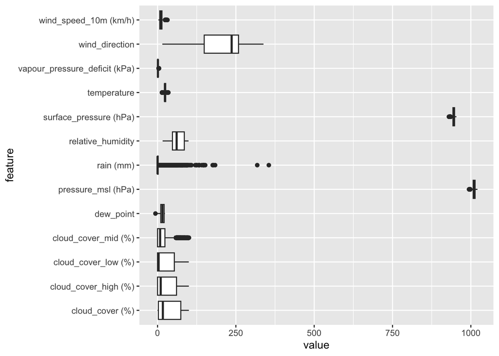

```r
data %>%
  select(-time, -willTomorrowRain) %>%
  gather(key = "feature", value = "value") %>%
  ggplot(aes(x = feature, y = value)) +
  geom_boxplot() +
  coord_flip()
```

By looking at the plot is evident that the variables have different scales and/or are skewed, so the data needs to be normalized.

```r
data <- data %>%
  select(-time) %>%
  mutate_if(is.numeric, scale)
```

The procedure create some `NaN` values which will set to `0`

```r
data[is.na(data)] <- 0
```

Plot again the predictors after being normalized

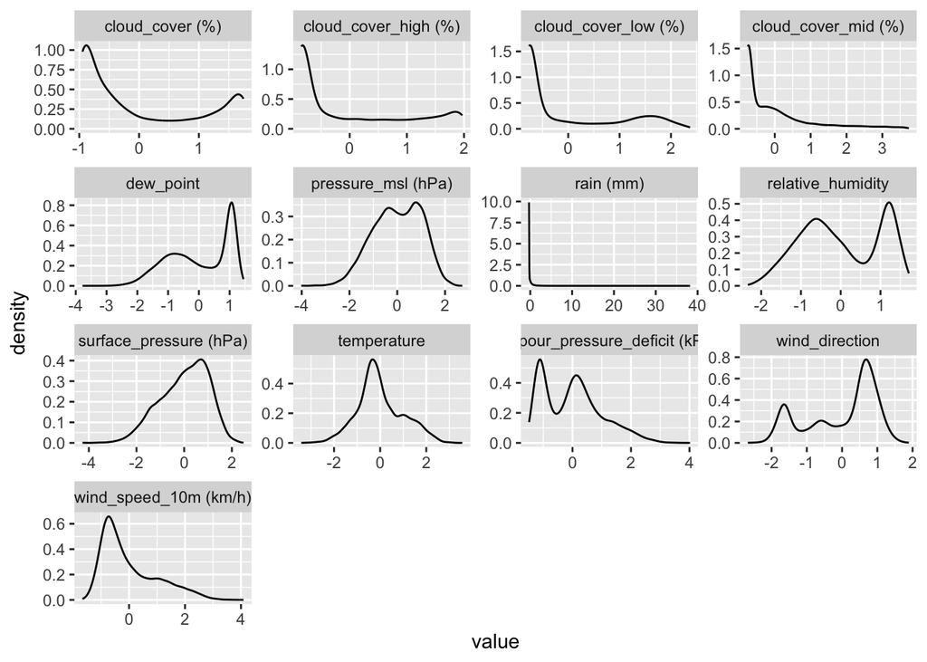

```r
data %>%
  select(-willTomorrowRain) %>%
  gather(key = "feature", value = "value") %>%
  ggplot(aes(x = value)) +
  geom_density() +
  facet_wrap(~feature, scales = "free")
```

```r
data
```

```
## # A tibble: 16,228 × 14
##    temperature[,1] relative_humidity[,1] dew_point[,1] `pressure_msl (hPa)`[,1]
##              <dbl>                 <dbl>         <dbl>                    <dbl>
##  1          -1.53                 0.347        -0.283                     0.579
##  2          -1.77                 0.249        -0.532                     0.709
##  3          -1.81                -0.311        -0.999                     0.830
##  4          -1.24                -0.397        -0.733                     0.847
##  5          -1.34                 0.425        -0.0955                    1.09
##  6          -1.33                 0.461        -0.0674                    1.39
##  7          -0.758                0.0597       -0.126                     1.47
##  8          -0.498               -0.0932       -0.132                     1.33
##  9          -0.471               -0.0993       -0.149                     1.15
## 10          -0.617               -0.207        -0.328                     0.792
## # ℹ 16,218 more rows
## # ℹ 10 more variables: `surface_pressure (hPa)` <dbl[,1]>,
## #   `cloud_cover (%)` <dbl[,1]>, `cloud_cover_low (%)` <dbl[,1]>,
## #   `cloud_cover_mid (%)` <dbl[,1]>, `cloud_cover_high (%)` <dbl[,1]>,
## #   `vapour_pressure_deficit (kPa)` <dbl[,1]>,
## #   `wind_speed_10m (km/h)` <dbl[,1]>, wind_direction <dbl[,1]>,
## #   `rain (mm)` <dbl[,1]>, willTomorrowRain <fct>
```

# Data preparation

Set the `seed` in order to allow reproducibility of the project

```r
set.seed(0)
```

Split the data into `train` and `test` set

```r
train_index <- sample(1:nrow(data), 0.8 * nrow(data))
train <- data[train_index, ]
test <- data[-train_index, ]
```

## Model

The first model implemented is the random forest model

```r
tune_rf_spec <- rand_forest(
  mtry = 13,
  trees = 2000,
  mode = "classification"
) %>%
  set_engine("ranger", importance = "impurity")

# Create a recipe for pre-processing
rain_rf_recipe <- recipe(willTomorrowRain ~ ., data = train) %>%
  step_dummy(all_nominal_predictors()) %>%
  step_zv(all_predictors())

# Create a workflow to combine the model and the recipe
rf_workflow <- workflow() %>%
  add_model(tune_rf_spec) %>%
  add_recipe(rain_rf_recipe)
```

Fit the model to the train

```r
rf_fit <- fit(rf_workflow, data = train)
```

Evaluate performances

```r
# Evaluate the model's performance on the training set
train_predictions <- rf_fit %>%
  predict(train) %>%
  bind_cols(train)

# Evaluate the model's performance on the test set
test_predictions <- rf_fit %>%
  predict(test) %>%
  bind_cols(test)
```

Calculate metrics

```r
# Calculate metrics for training set
train_metrics <- train_predictions %>%
  metrics(truth = willTomorrowRain, estimate = .pred_class)

# Calculate metrics for test set
test_metrics <- test_predictions %>%
  metrics(truth = willTomorrowRain, estimate = .pred_class)
```

```r
print(train_metrics)
```

```
## # A tibble: 2 × 3
##   .metric  .estimator .estimate
##   <chr>    <chr>          <dbl>
## 1 accuracy binary         0.989
## 2 kap      binary         0.978
```

```r
print(test_metrics)
```

```
## # A tibble: 2 × 3
##   .metric  .estimator .estimate
##   <chr>    <chr>          <dbl>
## 1 accuracy binary         0.919
## 2 kap      binary         0.830
```

From this output a little but of overfitting is present since the accuracy on the training set is present

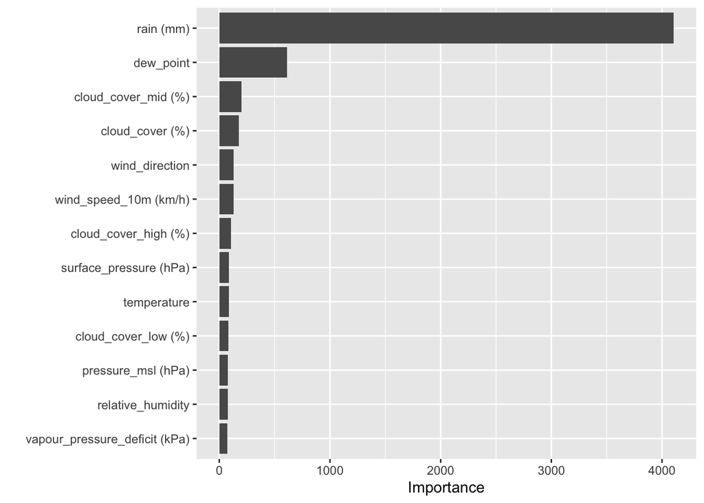

```r
# Variable importance
rf_fit %>%
  pull_workflow_fit() %>%
  vip(num_features = 13)
```

Can be trivial to say that a precipitation today will forecast rain tomorrow, but this suggest that the place where this data was recorded had in general several days of consevutive rain

Now a smaller forest can be tried to compare the results

```r
# Define the random forest model specification
tune_rf_spec <- rand_forest(
  mtry = 13,
  trees = 250,
  mode = "classification"
) %>%
  set_engine("ranger", importance = "impurity")

# Create a workflow to combine the model and the recipe
rf_workflow <- workflow() %>%
  add_model(tune_rf_spec) %>%
  add_recipe(rain_rf_recipe)
```

```r
rf_fit <- fit(rf_workflow, data = train)
```

```r
# Evaluate the model's performance on the training set
train_predictions <- rf_fit %>%
  predict(train) %>%
  bind_cols(train)

# Evaluate the model's performance on the test set
test_predictions <- rf_fit %>%
  predict(test) %>%
  bind_cols(test)

# Calculate metrics for training set
train_metrics <- train_predictions %>%
  metrics(truth = willTomorrowRain, estimate = .pred_class)

# Calculate metrics for test set
test_metrics <- test_predictions %>%
  metrics(truth = willTomorrowRain, estimate = .pred_class)
```

```r
print(train_metrics)
```

```
## # A tibble: 2 × 3
##   .metric  .estimator .estimate
##   <chr>    <chr>          <dbl>
## 1 accuracy binary         0.989
## 2 kap      binary         0.976
```

```r
print(test_metrics)
```

```
## # A tibble: 2 × 3
##   .metric  .estimator .estimate
##   <chr>    <chr>          <dbl>
## 1 accuracy binary         0.921
## 2 kap      binary         0.834
```

Variable importance

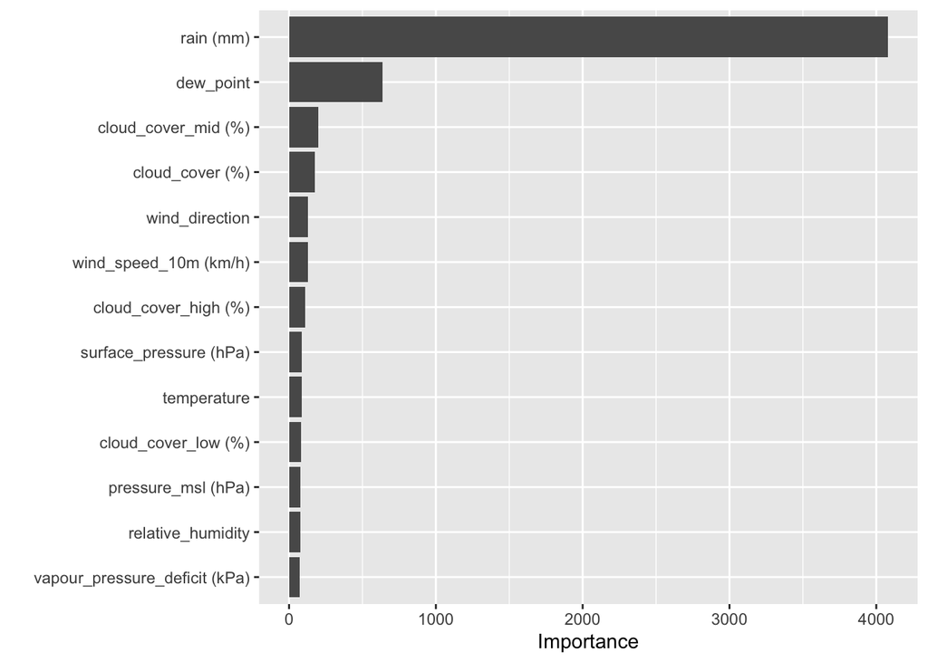

```r
# Variable importance
rf_fit %>%
  pull_workflow_fit() %>%
  vip(num_features = 13)
```

The results are similar to the previous but slightly better.

Now let’s try a random search

```r
# Define the random forest model specification with tuning parameters
tune_rf_spec <- rand_forest(
  mtry = tune(),
  trees = tune(),
  min_n = tune(),
  mode = "classification"
) %>%
  set_engine("ranger", num.threads = 7)

# Create cross-validation folds
data_folds <- vfold_cv(data)

# Create a recipe for pre-processing
# Create a recipe for pre-processing
rain_rf_recipe <- recipe(willTomorrowRain ~ ., data = train) %>%
  step_dummy(all_nominal_predictors()) %>%
  step_zv(all_predictors())

# Create a workflow to combine the model and the recipe
rain_rf_wflow <- workflow() %>%
  add_model(tune_rf_spec) %>%
  add_recipe(rain_rf_recipe)

# Define the metrics to evaluate
metr_res <- metric_set(kap, accuracy)

# Perform random search tuning
rf_reg_tune <- rain_rf_wflow %>%
  tune_grid(
    data_folds,
    grid = grid_random(
      trees(range = c(100, 1000)),
      mtry(range = c(8, 13)),
      min_n(range = c(6, 8)),
      size = 5
    ),
    metrics = metr_res
  )

# Collect and print the metrics
rf_reg_tune %>% collect_metrics()
```

```
## # A tibble: 10 × 9
##     mtry trees min_n .metric  .estimator  mean     n std_err .config
##    <int> <int> <int> <chr>    <chr>      <dbl> <int>   <dbl> <chr>
##  1    10   363     6 accuracy binary     0.920    10 0.00274 Preprocessor1_Mode…
##  2    10   363     6 kap      binary     0.832    10 0.00562 Preprocessor1_Mode…
##  3     8   282     7 accuracy binary     0.921    10 0.00291 Preprocessor1_Mode…
##  4     8   282     7 kap      binary     0.834    10 0.00595 Preprocessor1_Mode…
##  5     8   785     7 accuracy binary     0.922    10 0.00288 Preprocessor1_Mode…
##  6     8   785     7 kap      binary     0.835    10 0.00584 Preprocessor1_Mode…
##  7    11   344     6 accuracy binary     0.921    10 0.00259 Preprocessor1_Mode…
##  8    11   344     6 kap      binary     0.833    10 0.00532 Preprocessor1_Mode…
##  9     9   452     7 accuracy binary     0.920    10 0.00298 Preprocessor1_Mode…
## 10     9   452     7 kap      binary     0.832    10 0.00608 Preprocessor1_Mode…
```

```r
# Select the best configuration based on the "kap" metric
best_f1 <- rf_reg_tune %>% select_best(metric = "kap")

# Finalize the model with the best configuration
final_rf <- finalize_model(tune_rf_spec, best_f1)

# Print the best result configuration
print(best_f1)
```

```
## # A tibble: 1 × 4
##    mtry trees min_n .config
##   <int> <int> <int> <chr>
## 1     8   785     7 Preprocessor1_Model3
```

```r
# Output the final model
final_rf
```

```
## Random Forest Model Specification (classification)
##
## Main Arguments:
##   mtry = 8
##   trees = 785
##   min_n = 7
##
## Engine-Specific Arguments:
##   num.threads = 7
##
## Computational engine: ranger
```

## Extreme Gradient Boosting

Now another model is implemented, the Extreme Gradient Boosting.

```r
# Define the XGBoost model specification with tuning parameters
tune_btree_spec <- boost_tree(
  learn_rate = tune(),
  tree_depth = tune(),
  trees = tune(),
  mode = "classification"
) %>%
  set_engine("xgboost", nthreads = parallel::detectCores())

# Create cross-validation folds
rain_folds <- vfold_cv(train)

# Create a recipe for preprocessing
rain_rf_recipe <- recipe(willTomorrowRain ~ ., data = train) %>%
  step_dummy(all_nominal_predictors()) %>%
  step_zv(all_predictors())

# Create a workflow to combine the model and the recipe
btree_wflow <- workflow() %>%
  add_model(tune_btree_spec) %>%
  add_recipe(rain_rf_recipe)

# Define the metrics to evaluate
metr_res <- metric_set(kap, accuracy)

# Perform random search tuning
btree_reg_tune <- btree_wflow %>%
  tune_grid(
    rain_folds,
    grid = grid_random(
      learn_rate(),
      tree_depth(range = c(2, 8)),
      trees(range = c(5, 20)),
      size = 10
    ),
    metrics = metr_res
  )

# Collect and print the metrics
btree_reg_tune %>% collect_metrics()
```

```
## # A tibble: 20 × 9
##    trees tree_depth learn_rate .metric  .estimator  mean     n std_err .config
##    <int>      <int>      <dbl> <chr>    <chr>      <dbl> <int>   <dbl> <chr>
##  1    11          8   2.60e-10 accuracy binary     0.603    10 0.00420 Preproce…
##  2    11          8   2.60e-10 kap      binary     0        10 0       Preproce…
##  3    16          4   1.04e- 8 accuracy binary     0.908    10 0.00401 Preproce…
##  4    16          4   1.04e- 8 kap      binary     0.802    10 0.00889 Preproce…
##  5     7          2   9.36e- 8 accuracy binary     0.910    10 0.00368 Preproce…
##  6     7          2   9.36e- 8 kap      binary     0.809    10 0.00811 Preproce…
##  7    19          4   2.23e- 7 accuracy binary     0.919    10 0.00361 Preproce…
##  8    19          4   2.23e- 7 kap      binary     0.829    10 0.00796 Preproce…
##  9    18          2   1.86e- 6 accuracy binary     0.915    10 0.00357 Preproce…
## 10    18          2   1.86e- 6 kap      binary     0.821    10 0.00802 Preproce…
## 11     7          5   3.01e- 6 accuracy binary     0.919    10 0.00342 Preproce…
## 12     7          5   3.01e- 6 kap      binary     0.828    10 0.00754 Preproce…
## 13    14          7   7.13e- 6 accuracy binary     0.914    10 0.00356 Preproce…
## 14    14          7   7.13e- 6 kap      binary     0.819    10 0.00778 Preproce…
## 15    17          8   2.34e- 5 accuracy binary     0.912    10 0.00338 Preproce…
## 16    17          8   2.34e- 5 kap      binary     0.813    10 0.00729 Preproce…
## 17     8          8   9.64e- 3 accuracy binary     0.913    10 0.00328 Preproce…
## 18     8          8   9.64e- 3 kap      binary     0.816    10 0.00719 Preproce…
## 19    11          4   3.37e- 2 accuracy binary     0.921    10 0.00341 Preproce…
## 20    11          4   3.37e- 2 kap      binary     0.833    10 0.00748 Preproce…
```

```r
# Select the best configuration based on the "kap" metric
best_btree_f1 <- btree_reg_tune %>% select_best(metric = "kap")

# Finalize the model with the best configuration
final_btree <- finalize_model(tune_btree_spec, best_btree_f1)

# Print the best result configuration
print(best_btree_f1)
```

```
## # A tibble: 1 × 4
##   trees tree_depth learn_rate .config
##   <int>      <int>      <dbl> <chr>
## 1    11          4     0.0337 Preprocessor1_Model10
```

```r
# Output the final model
final_btree
```

```
## Boosted Tree Model Specification (classification)
##
## Main Arguments:
##   trees = 11
##   tree_depth = 4
##   learn_rate = 0.0336638381492129
##
## Engine-Specific Arguments:
##   nthreads = parallel::detectCores()
##
## Computational engine: xgboost
```

Calculate the accuracy

```r
# Define the formula for the model
formula <- willTomorrowRain ~ .

# Fit the model to the training data using the formula
final_btree_fit <- fit(final_btree, formula = formula, data = train)
```

```
## [19:35:18] WARNING: src/learner.cc:767:
## Parameters: { "nthreads" } are not used.
```

```r
# Evaluate the model's performance on the training set
train_predictions <- final_btree_fit %>%
  predict(train) %>%
  bind_cols(train)

# Evaluate the model's performance on the test set
test_predictions <- final_btree_fit %>%
  predict(test) %>%
  bind_cols(test)

# Calculate metrics for training set
train_metrics <- train_predictions %>%
  metrics(truth = willTomorrowRain, estimate = .pred_class)

# Calculate metrics for test set
test_metrics <- test_predictions %>%
  metrics(truth = willTomorrowRain, estimate = .pred_class)
```

Print the train metrics

```r
print(train_metrics)
```

```
## # A tibble: 2 × 3
##   .metric  .estimator .estimate
##   <chr>    <chr>          <dbl>
## 1 accuracy binary         0.925
## 2 kap      binary         0.842
```

Print the test metrics

```r
print(test_metrics)
```

```
## # A tibble: 2 × 3
##   .metric  .estimator .estimate
##   <chr>    <chr>          <dbl>
## 1 accuracy binary         0.917
## 2 kap      binary         0.825
```

```r
# Assuming final_btree is the finalized model specification
# Create a new workflow with the finalized model
final_btree_wflow <- workflow() %>%
  add_model(final_btree) %>%
  add_recipe(rain_rf_recipe)

# Fit the workflow to the training data
final_btree_fit <- fit(final_btree_wflow, data = train)
```

```
## [19:35:18] WARNING: src/learner.cc:767:
## Parameters: { "nthreads" } are not used.
```

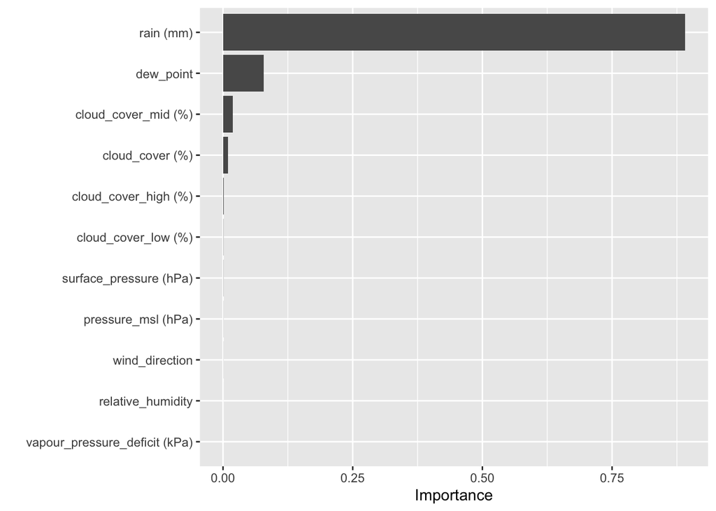

```r
# Plot the variable importance
final_btree_fit %>%
  pull_workflow_fit() %>%
  vip(num_features = 13)
```

The tree can be plotted to better visualize it

```r
xgb_model <- final_btree_fit %>%
  pull_workflow_fit() %>%
  .$fit
# Visualize the first tree in the model
xgb.plot.tree(model = xgb_model, trees = 0)
```

[interactive chart not shown]

## Conclusion

This project evaluated the effectiveness of Random Forest and Extreme Gradient Boosting (XGBoost) in the classification of weather data to predict the likelihood of rain on the following day. The dataset, originally structured as a time series, was preprocessed to be treated as independent observations for modeling purposes.

The results demonstrated that Random Forest outperformed XGBoost in this particular case. Both models highlighted the significance of the amount of rainfall on the current day as the primary predictor of whether it would rain the next day. The presence or absence of rainfall was a critical factor in determining whether the subsequent day would also be classified as rainy. However, one notable limitation of this approach is that rain occurring overnight (for example, during a storm that spans midnight) may result in the following day being classified as rainy, even if precipitation occurred only briefly after midnight.

The second most important variable identified by both models was the dew_point, indicating the relevance of the relationship between humidity and temperature in predicting rainfall. This finding suggests that atmospheric moisture, as captured by the dew point, plays a critical role in determining rain conditions for the next day.